# Seguimiento a largo plazo de reptiles en Doñana 2005-2021

Sergio Picó Jordá[^1], María Hurtado de Mendoza Romo[^2]

# Seguimiento a largo plazo de reptiles en Doñana 2005-2021

## Introducción

El monitoreo anual de reptiles en el Espacio Natural de Doñana (END) se inició en el año 2005 con el objetivo de detectar cambios y tendencias en las poblaciones de estos animales.

El monitoreo se hace anualmente en primavera y otoño realizando 7 transectos en distintos hábitats, durante los que se registran todas las observaciones de las especie de interés.

DOI: https://doi.org/10.15470/ki0cn7

## Distribución espacial de las observaciones

[interactive chart not shown]

Figura 1. Mapa de las observaciones registradas

## Tendencias temporales de las especies estudiadas

Las especies muestran fluctuaciones anuales que parecen estar correlacionadas, probablemente por un efecto común de variables ambientales.

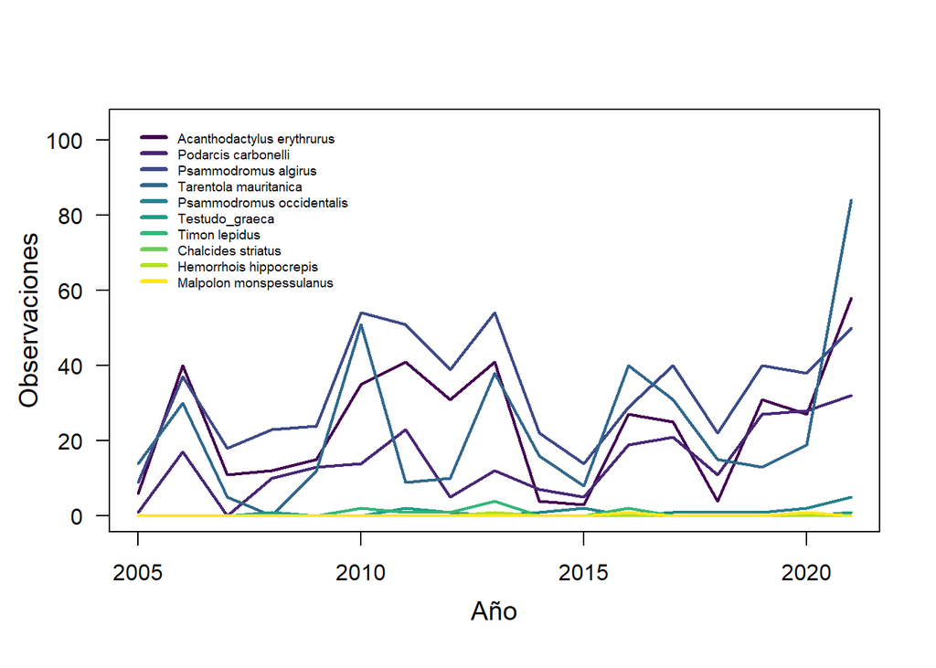

Figura 2. Tendencias temporales de las especies estudiadas en el periodo 2005-2021.

# Detección de tendencias poblacionales

Aplicamos regresiones lineales a los datos de cada especie para tratar de detectar si existen tendencias.

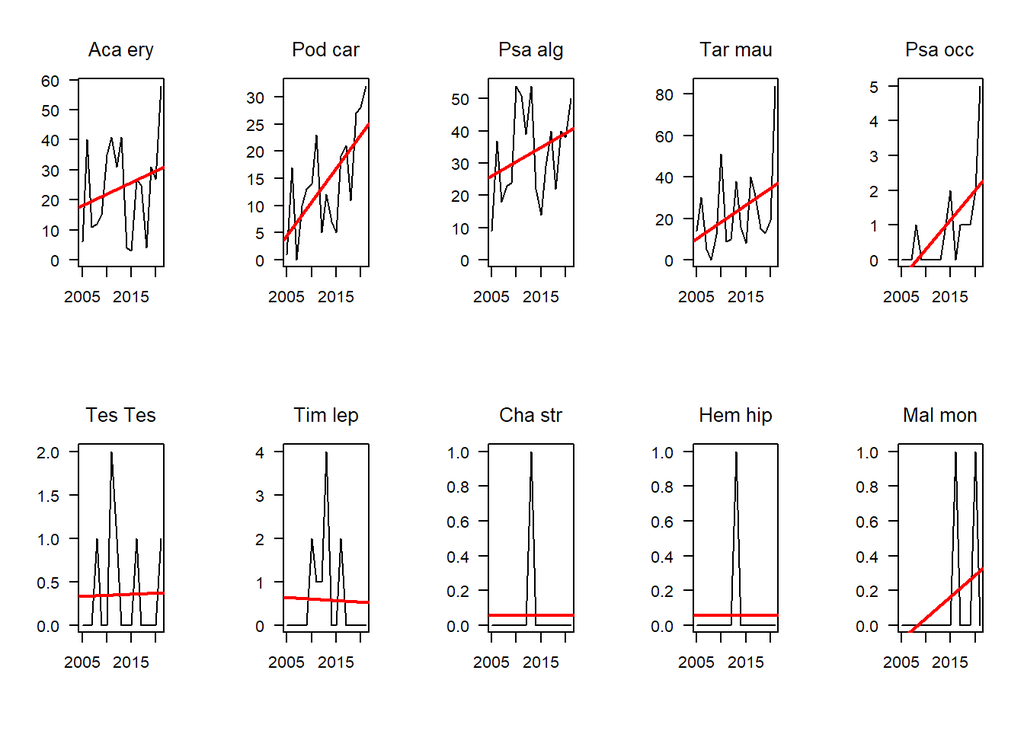

Figura 3. Detalle de las poblaciones estudiadas. En cada caso, la tendencia está representada por la línea roja.

# Sincronía de las poblaciones de reptiles de Doñana

Calculamos dos métricas de sincronía basadas en el ratio de la varianza de la comunidad y la varianza de las especies (phi) y en la correlación media (eta). Ambas nos indican que la comunidad tiene sincronía alta, pues phi tiene rango de 0 (mínima sincronía) a 1 (máxima sincronía) y eta de -1 (máxima asincronía) a 1 (máxima sincronía).

```
## [1] "Phi =0.71"
```

```
## [1] "Eta =0.77"
```

[^1]: Universidad de Cádiz, sergio.pico@uca.es
[^2]: Universidad de Cádiz, maria.hurtadodemendoza@uca.es